# scCloneVar Workflow

Chris Chen

2026-07-30

# Overview

This vignette demonstrates a complete **scCloneVar workflow** using the included demo dataset (scCloneVar_test_demo).

The analysis proceeds through the following stages:

1. Clone size distribution profiling
2. Output Activity (OA) analysis
3. Clone-wise differential expression
4. Transcriptional heterogeneity analysis (PCA-based distances)
5. Differential variance (DVG) analysis
6. GSEA on ranked heterogeneity statistics

## Load Package and Demo Data

```r
suppressPackageStartupMessages({library(scCloneVar)
  library(Seurat)})

data(scCloneVar_test_demo)

seurat_obj <- scCloneVar_test_demo
```

```r
seurat_obj
```

```
#> An object of class Seurat
#> 14404 features across 136 samples within 1 assay
#> Active assay: RNA (14404 features, 1805 variable features)
#>  3 layers present: scale.data, data, counts
#>  3 dimensional reductions calculated: pca, harmony, umap
```

# Clone Size Distribution

This step visualizes clone expansion patterns and computes descriptive statistics across samples.

Clonal expansion is a fundamental property of hematopoietic dynamics, reflecting the proliferative fitness and competitive advantage of individual clones within a sample. Quantifying relative clone size allows comparison across replicates and conditions while controlling for differences in total cell number.

For each replicate, relative clone frequency is defined as:

Relative clone frequency is calculated as

$$\mathrm{RelFreq} =
\frac{\text{cells in clone}}{\text{total cells in replicate}}$$

Clones below a user-defined frequency threshold are grouped as Other, enabling clearer visualization of dominant expansions.

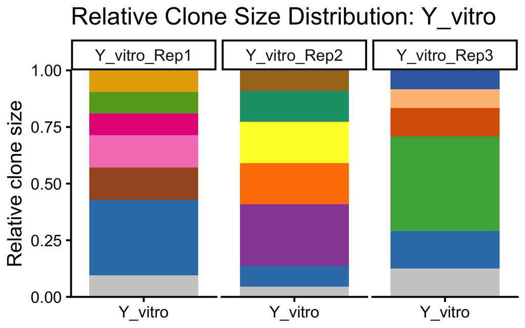

```r
comparison_list <- list(
  list(seurat_obj = seurat_obj,samples = grep("^Y_vitro", unique(seurat_obj$sampleName), value = TRUE),label_counts = data.frame(
      Sample = grep("^Y_vitro", unique(seurat_obj$sampleName), value = TRUE),
      Replicate = unique(seurat_obj$Rep[grepl("^Y_vitro", seurat_obj$sampleName)]),
      SampleLabel = grep("^Y_vitro", unique(seurat_obj$sampleName), value = TRUE)),
    threshold = 0.05,
    title = "Relative Clone Size Distribution: Y_vitro",
    name = "Y_vitro"),
  list(
    seurat_obj = seurat_obj,
    samples = grep("^O_vitro", unique(seurat_obj$sampleName), value = TRUE),
    label_counts = data.frame(
      Sample = grep("^O_vitro", unique(seurat_obj$sampleName), value = TRUE),
      Replicate = unique(seurat_obj$Rep[grepl("^O_vitro", seurat_obj$sampleName)]),
      SampleLabel = grep("^O_vitro", unique(seurat_obj$sampleName), value = TRUE)),
    threshold = 0.05,
    title = "Relative Clone Size Distribution: O_vitro",
    name = "O_vitro"))

dist_out <- run_clone_distribution_engine(comparison_list)

dist_out$plots$Y_vitro
```

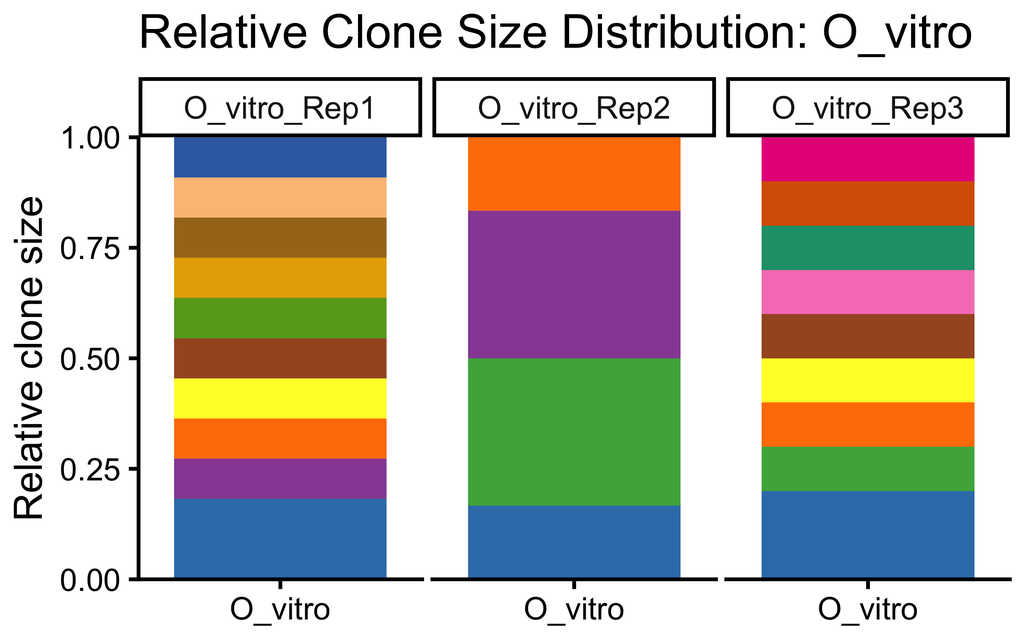

```r
dist_out$plots$O_vitro
```

Relative clonal size summary table is also provided:

```r
dist_out$descriptive_stats$Y_vitro
```

| sampleName | n_clones | min_freq | max_freq | mean_freq |
| --- | --- | --- | --- | --- |
| O_vitro | 20 | 0.01492537 | 0.1194030 | 0.05 |
| Y_vitro | 20 | 0.01449275 | 0.1884058 | 0.05 |

# Output Activity (OA) Analysis

This step quantifies clone-level output bias and classifies clones into low and high output groups.

Output Activity (OA) measures the differentiation bias of each clone by comparing its contribution to non-HSC versus HSC compartments. Following the conceptual framework described by Singh et al., Cell Stem Cell (2025) https://www.cell.com/cell-stem-cell/fulltext/S1934-5909(25)00012-8, OA reflects the functional output potential of a clone — that is, whether a clone preferentially produces differentiated progeny or remains stem-biased. In this implementation, OA is computed as the relative enrichment of non-HSC output normalized to HSC contribution within each clone.

For a given clone $c$, Output Activity is defined as:

$$\mathrm{OA}_c =
\frac{\mathrm{nonHSC\_freq}_c + \epsilon}
{\mathrm{HSC\_freq}_c + \epsilon}$$

and

$$\epsilon = 10^{-6}$$

Higher OA values indicate clones with greater differentiation output potential, whereas lower OA values represent stem-biased clones.

## Required Inputs

The function requires a Seurat object containing: - A UMAP reduction named “umap”, - Metadata columns specifying celltype and clone identity (default “CloneID”), - Defined HSC cell types (default: LT-HSC, ST-HSC). - Optional arguments allow specification of non-HSC cell types, DEG cell subsets, reference marker lists, color mappings, and statistical thresholds.

```r
# Define low and high output marker

low_output_markers <- c(
  "Mpl","Ifitm3","Ifitm1","Tgm2","H2-K1","Socs2","Mycn","Nupr1","Hacd4",
  "Mllt3","Gda","B2m","Procr","Txnip","Clu","Sult1a1","S100a6","Rpl36a",
  "Tsc22d1","Gng11","Ccnd2","mt-Co3","Tmem176b","Lmo2","Ly6a","Mmrn1",
  "Trim47","St3gal1","Mecom","Pik3r1","Adgrg1","Esam","Ryk","Rps21","Hoxb8",
  "Ccnd1","Uba7","Rps28","Serpina3g","Rpl37a","Fkbp1a","Pdzk1ip1","Selp",
  "Eif4a2","Tmem176a","Bex4","Grb10","Jam3","Ptk2b","Gimap8","Csgalnact1",
  "H2-Q7","App","Mylk","Casp12","Rhof","Laptm4a","Tcf15","Gabarapl1","Ctsl",
  "Bex1","Rpl21","D630039A03Rik","Myof","Glul","Ppic","Tpt1","Rpl5","Cdkn1c",
  "mt-Nd5","Abcg3","Aplp2","Art4","Tbxas1","Cish","Vwf","Scarf1","mt-Atp6",
  "H2-Eb1","H2-D1","Cd74","Iigp1","Aldh1a1","Gstm1","mt-Nd4","mt-Cytb","mt-Co1"
)
high_output_markers <- c(
  "Plac8","H2afy","Cdk6","Cd34","Nkg7","Ptma","Mpo","Cd48","Stmn1","Fam117a",
  "Slc22a3","Adgrg3","Ppia","Car1","Ctsg","Flt3","Lgals1","Muc4","Gpx1",
  "Hmgb2","Ndufa4","Serpinb1a","Ccl9","Oaz1","H2afz","Crip1","Mcm7","Cpa3",
  "Vim","Ybx1","Sell","Sh3bgrl3","H3f3a","Dut","Atpif1","Ran","Hnrnpa2b1",
  "Hdgf","Mcm4","Elane","Rabgap1l","Cmtm7","Rpsa","Mcm6","Plek","Set","Atp5g3",
  "Myc","Taldo1","Tuba1b","Cks2","Slc25a5","Fam65a","Cebpa","Tmsb10","Cd52",
  "Klf1","Anp32b","Hn1","Parvg","Ffar2","Bex6","Emilin2","Itgal","Cox5a",
  "Hnrnpab","Ighm","BC035044","Lmnb1","Golm1","Bin1","Igfbp4","Tyrobp","E2f8",
  "Banf1","Cst7","Sh2d5","Aqp1","Ptbp3","Snrpf","Rfc2","Ramp1","Hmgn5","Nme1"
)
# Can be set to NULL if no comparison needed, for simplicity we show a few genes here
ref_deg_genes_list <- c("Olfm3","Scin","Tox","Pbx3","Mecom","Fry","Slc24a3","Pcdh7" )
```

```r
## Define celltype colors manually ##
celltype_colors <- c(
  ## HSCs
  "LT-HSC" = "#E76F51",
  "ST-HSC" = "#F4A261",
  ## Early progenitors
  "MPP"  = "#5BC374",
  "MPP3" = "#4CAF50",
  "MPP4" = "#66CDAA",
  "CMP"  = "#C49A6C",
  "EryP" = "#F28E2B",
  "LMPP" = "#4DB6AC",
  ## Myeloid differentiation
  "GMP"   = "#1FA187",
  "GMP-3" = "#2BBBAD",
  "MDP"   = "#7C9A3D",
  "Granulocyte" = "#6C8EBF",
  ## Megakaryocyte / Platelet
  "MkP"   = "#5FBAC8",
  "MKP"   = "#4DA8B5",
  "MKP-1" = "#78C2D0",
  ## Erythroid / Megakaryocyte
  "MEP"     = "#8C973E",
  "MEP-1"   = "#7A8735",
  "MEP-2"   = "#9AAE4C",
  "MEP/EryP"= "#A4B95A",
  ## Mast / Basophil
  "Ba/mast"   = "#C77DFF",
  "Mast-cell" = "#B565D9",
  ## Immune / Other
  "DC"  = "#9E6E4A",
  "Mac" = "#7F5539",
  "Mast-Cells" = "#D98BB8",
  ## T cell
  "T-cells" = "#6CA3D1",
  "T-cell"  = "#4F8AC9",
  "T-Cell"  = "#83B8E6",
  ## Undefined
  "UN" = "grey65")

## Run OA function ##

oa_out <- run_low_high_OA_analysis_for_a_single_sample(seurat_obj = seurat_obj,
  sample_label = "DemoSample",celltype_colors = celltype_colors,low_output_markers = low_output_markers,
  high_output_markers = high_output_markers, full_ref_deg_genes_list = ref_deg_genes_list,
  umap_reduction = 'umap')
```

## Expected Outputs

The function returns a structured results object (also saved to disk) containing: - Per-clone OA values and low/high classifications - Cell-level OA annotations

```r
head(oa_out$OA_by_clone) # Clone-level OA values
```

| CloneID | HSC | nonHSC | total_HSC_all | total_nonHSC_all | HSC_freq | nonHSC_freq | OA | log2OA |
| --- | --- | --- | --- | --- | --- | --- | --- | --- |
| Old_C_1010 | 2 | 0 | 83 | 53 | 0.02409639 | 0.00000000 | 4.149828e-05 | -14.55658901 |
| Old_C_1030 | 2 | 0 | 83 | 53 | 0.02409639 | 0.00000000 | 4.149828e-05 | -14.55658901 |
| Old_C_1065 | 1 | 0 | 83 | 53 | 0.01204819 | 0.00000000 | 8.299311e-05 | -13.55664888 |
| Old_C_112 | 5 | 3 | 83 | 53 | 0.06024096 | 0.05660377 | 9.396236e-01 | -0.08984508 |
| Old_C_1459 | 0 | 2 | 83 | 53 | 0.00000000 | 0.03773585 | 3.773685e+04 | 15.20368635 |
| Old_C_1577 | 0 | 2 | 83 | 53 | 0.00000000 | 0.03773585 | 3.773685e+04 | 15.20368635 |

```r
head(oa_out$OA_by_cell)  # Cell-level OA values
```

|  | cell_ID | CloneID | OA |
| --- | --- | --- | --- |
| 1 | O_vitro_AAAGAACTCAAGAAAC-1 | Old_C_51 | 1.044024 |
| 2 | O_vitro_AAGTGAACAGTTCACA-1 | Old_C_392 | 1.044024 |
| 3 | O_vitro_ACAAAGAGTACCGTCG-1 | Old_C_51 | 1.044024 |
| 4 | O_vitro_ACCTACCTCGCAGTTA-1 | Old_C_680 | 1.566026 |
| 5 | O_vitro_ACTGCAATCTTACTGT-1 | Old_C_51 | 1.044024 |
| 6 | O_vitro_ACTTCGCTCTTACCAT-1 | Old_C_859 | 1.565991 |

-Clone-wise DEG results (via run_clonewise_DEG_suite())

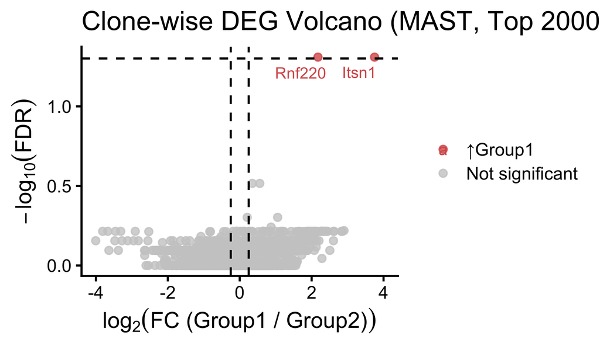

```r
oa_out$DEG_results$volcano_plot
```

-UMAP visualizations (cell type, OA gradient, contour)

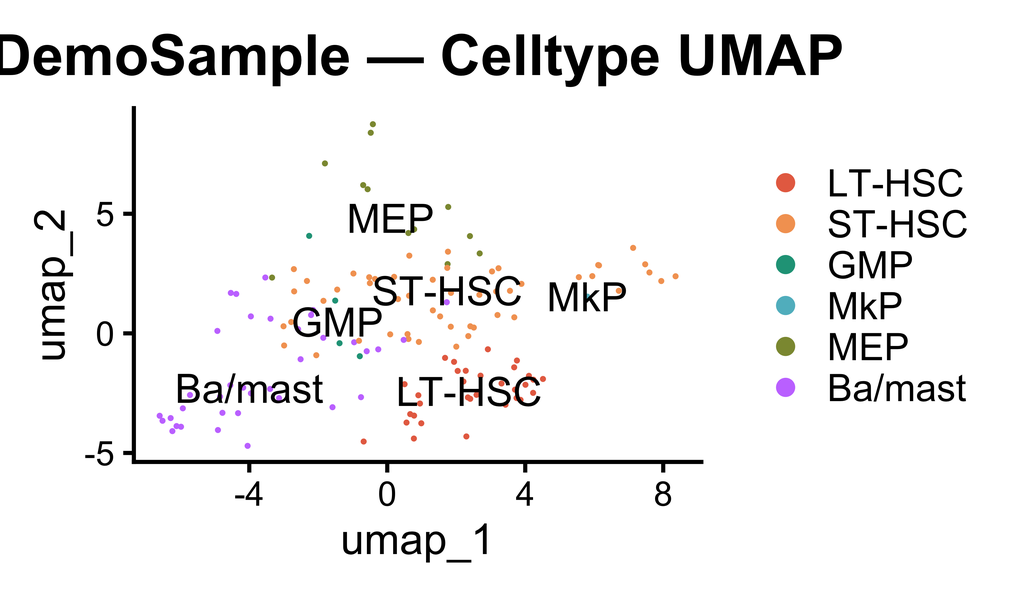

```r
oa_out$plot_dim
```

-Universe-restricted enrichment tests

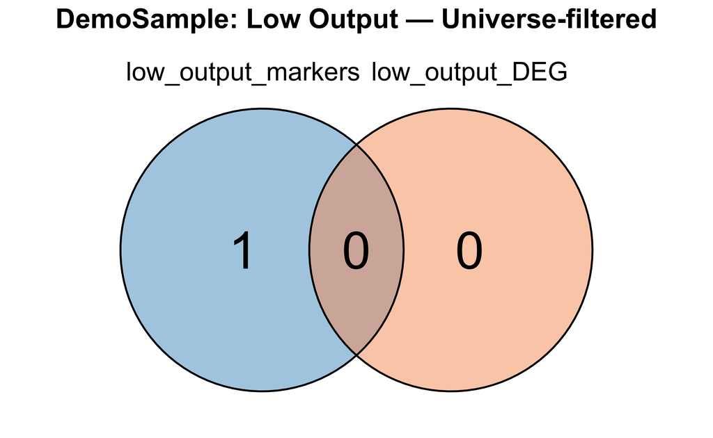

```r
oa_out$plot_venn_filtered
```

Density across celltypes

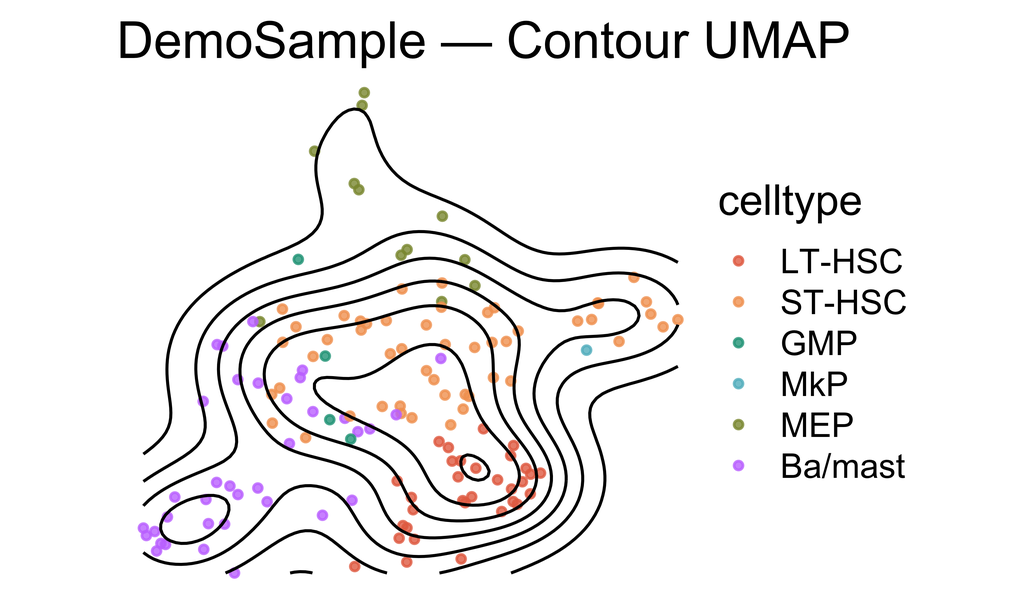

```r
oa_out$plot_contour
```

-A complete RDS object consolidating tables and plots.

# Clone-wise Differential Expression

Differential expression analysis between low and high OA clones.

We next perform clone-wise differential expression analysis by directly comparing cells derived from low-output (stem-biased) versus high-output (differentiation-biased) clones. This design tests whether transcriptional programs differ as a function of clonal output activity and linking functional clone behavior to gene expression changes.

```r
deg_out <- run_clonewise_DEG_suite(
  seurat_obj = seurat_obj, clone_set1_ids = oa_out$low_clones, clone_set2_ids = oa_out$high_clones,
  clone_col = "CloneID", assay_name  = "RNA", top_hvgs  = 2000, min_detect_prop = 0.10,
  min_mean_norm = 0.10, min_mean_raw = 2, fc_cutoff  = 0.25, fdr_cutoff = 0.05,)
```

### Volcano Plots (clone-wise DEGs)

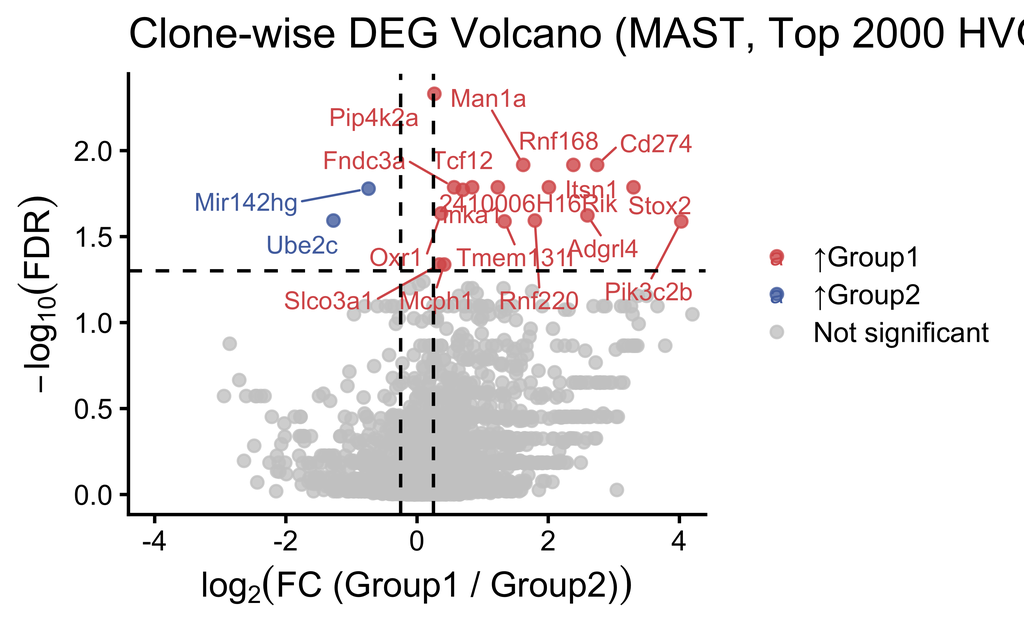

```r
deg_out$volcano_plot
```

# PCA-Based Clone Heterogeneity

Quantifies intra- and inter-clonal transcriptional distances in PCA space.

Intra-clonal distance

We first embed all cells into PCA space (top n PCs). For each clone, we compute its clone centroid as the mean PC coordinate vector across cells in that clone, then quantify intra-clonal heterogeneity as the average Euclidean distance from each cell to its own clone centroid (i.e., within-clone dispersion).

Inter-clonal distance

To quantify inter-clonal heterogeneity, we compute (for each clone A) the average Euclidean distance from cells in clone A to the centroid of every other clone B, and then take the mean across B to obtain a per-clone mean inter-clone distance (i.e., how far a clone sits from other clones in transcriptional PC space).

```r
het_out <- compute_pca_clone_heterogeneity(
    seu = seurat_obj,celltype_keep = c("LT-HSC", "ST-HSC"),
    clone_col = "CloneID", sample_col = "sampleName", assay = "RNA",
    n_pcs = 30, min_pct = 0.1, min_mean = 0.1, min_cells = 2, group_recode = NULL,
    sample_order = c("Y_vitro", "O_vitro"), prefix = "Clone Heterogeneity")
```

```
#>   |                                                                              |                                                                      |   0%
```

Summary table for intra and inter-clonal PCA distance

```r
head(het_out$summary)
```

| CloneID | sampleName | n_cells | intra_dist | centroid | mean_inter_dist |
| --- | --- | --- | --- | --- | --- |
| Old_C_51 | O_vitro | 3 | 22.72708 |  | 34.31592 |
| Old_C_392 | O_vitro | 3 | 35.07946 |  | 47.01101 |
| Old_C_680 | O_vitro | 4 | 35.52962 |  | 45.99609 |
| Old_C_859 | O_vitro | 1 | NA |  | NA |
| Old_C_904 | O_vitro | 2 | 13.94573 |  | 25.32967 |
| Old_C_1010 | O_vitro | 2 | 23.95213 |  | 37.67771 |

Within and between group statistical test

```r
print(het_out$within_group_tests)
```

```
#> # A tibble: 2 × 5
#>   sampleName  p_value intra_mean inter_mean label
#>   <fct>         <dbl>      <dbl>      <dbl> <chr>
#> 1 Y_vitro    0.000183       17.8       30.4 ***
#> 2 O_vitro    0.00129        25.2       37.1 **
```

```r
print(het_out$between_group_tests)
```

```
#> # A tibble: 2 × 5
#>   DistanceType group1  group2  p_value label
#>   <fct>        <chr>   <chr>     <dbl> <chr>
#> 1 Intra-clone  Y_vitro O_vitro  0.0102 *
#> 2 Inter-clone  Y_vitro O_vitro  0.0124 *
```

Intra and inter-clonal PCA distance violin plot

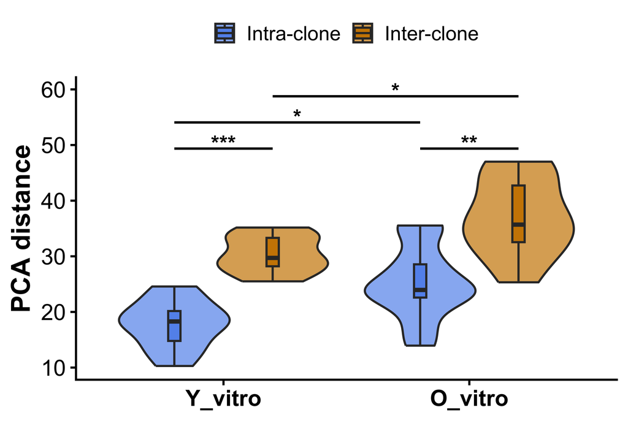

```r
het_out$plot
```

# Differential Variance Analysis

Identifies Differential Variance Genes (DVGs) across groups.

Beyond clone-level heterogeneity, it is often informative to examine transcriptional heterogeneity at the gene level. Variability analysis can reveal regulatory instability, transcriptional noise, or lineage priming effects that are not detectable through mean expression analysis alone.

To quantify transcriptional heterogeneity, the function compute_variance_metrics() identifies Differential Variability Genes (DVGs) between two biological groups. This function performs several complementary analyses:

Raw per-gene variance is strongly confounded by mean expression: highly expressed genes mechanically tend to show larger absolute variance, independent of any genuine difference in cell-to-cell variability. To remove this confound *before* testing rather than after, `compute_variance_metrics()` first computes each gene’s mean and variance within each group, pools these values across both groups, and fits a local polynomial regression (LOESS; Cleveland & Devlin, 1988) of log-variance on log-mean expression:

$$\log_{10}(\text{Var}_g) =
f\big(\log_{10}(\text{Mean}_g)\big) + \varepsilon_g$$

where $f(\cdot)$ is estimated by LOESS. A single trend is fit across both groups combined, rather than one curve per group. This reflects a key assumption: that the two groups share the same underlying mean-variance relationship, so that any real biological difference between groups is left in the residual rather than absorbed into the correction itself. This assumption is checkable directly, by confirming that both groups’ points track the same fitted curve rather than systematically diverging from it.

The fitted trend gives, for every gene, an expected variance at its own group’s mean expression level. Each cell’s expression value is then standardized by this expectation prior to testing:

$$X'_{ic} = \frac{X_{ic}}{\sqrt{\hat
f\left(\text{Mean}_{ig}\right)}}$$

## Brown–Forsythe Test

The Brown–Forsythe test evaluates whether variance differs between groups by computing deviations from the **group median**.

Group median:

$$\tilde{x}_j = \text{median}(x_{1j}, x_{2j}, \ldots, x_{n_j j})$$
Absolute deviations from the group median:

$$z_{ij} = |x_{ij} - \tilde{x}_j|$$

The ANOVA test statistic is:

$$F =
\frac{
(N-k)\sum_{j=1}^{k} n_j (\bar{z}_j - \bar{z})^2
}{
(k-1)\sum_{j=1}^{k}\sum_{i=1}^{n_j}(z_{ij}-\bar{z}_j)^2
}$$

where

$$\bar{z}_j =
\frac{1}{n_j}\sum_{i=1}^{n_j} z_{ij}$$

$$\bar{z} =
\frac{1}{N}\sum_{j=1}^{k}\sum_{i=1}^{n_j} z_{ij}$$

Before and after mean-adjusted variance correction:

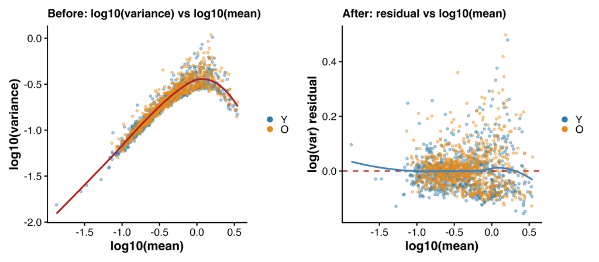

```r
knitr::include_graphics("Figures/Day0_MeanVariance_LOESS_Diagnostic.png")
```

```r
all_genes <- rownames(seurat_obj)
# For Mouse
genes_filtered <- all_genes[!grepl("^mt-", all_genes, ignore.case = TRUE) &
  !grepl("^Rps", all_genes) & !grepl("^Rpl", all_genes) &
  !grepl("^Hist", all_genes) &!grepl("^Gm[0-9]", all_genes) &
  !grepl("Rik$", all_genes)]

# For Human
#genes_filtered <- all_genes[!grepl("^MT-", all_genes, ignore.case = TRUE) &
#  !grepl("^RPS", all_genes) & !grepl("^RPL", all_genes) &
#  !grepl("^HIST", all_genes) & !grepl("^GM[0-9]", all_genes) &
#  !grepl("RIK$", all_genes)]

seurat_clean <- subset(seurat_obj, features = genes_filtered)
```

compute_variance_metrics() returns a per-gene heterogeneity assessment table Here we will be using the top 2000 high variable genes identified from seurat and perform 2 tests (brown_forsythe and levene)

```r
dvg_out <- compute_variance_metrics(
  seu = seurat_obj, layer  = "data", group_col = "donor_age", n_hvg = 2000,
  selection.method = "vst", n_cores = 1, chunk_size = 250,
  min_pct = 0.1, min_mean = 0.1)
```

Check the output tables

```r
head(dvg_out)
```

|  | gene | p_brown_forsythe | p_levene | var_Young | var_Old | log2FC_variance | fdr_brown_forsythe | fdr_levene | mean_adjusted_var_Young | mean_adjusted_var_Old | mean_adjusted_sd_Young | mean_adjusted_sd_Old | log2FC_mean_adjusted_variance | log2FC_mean_adjusted_SD |
| --- | --- | --- | --- | --- | --- | --- | --- | --- | --- | --- | --- | --- | --- | --- |
| 1 | Eya1 | 0.3480011176 | 0.0178093720 | 0.1256394 | 0.2201405 | 0.8091361 | 0.587913985 | 0.049956253 | 0.7975543 | 1.150214 | 0.8930590 | 1.072480 | 0.52824794 | 0.26412397 |
| 2 | Terf1 | 0.0003679054 | 0.0002229093 | 0.2057327 | 0.3902856 | 0.9237591 | 0.007621842 | 0.002419705 | 0.7389356 | 1.273359 | 0.8596136 | 1.128432 | 0.78511870 | 0.39255935 |
| 3 | Stau2 | 0.2140592999 | 0.2697362854 | 0.1698260 | 0.1565990 | -0.1169818 | 0.455682400 | 0.383883400 | 0.8964311 | 1.083810 | 0.9468004 | 1.041062 | 0.27384738 | 0.13692369 |
| 4 | Kcnq5 | 0.0661464996 | 0.0759006167 | 0.5742659 | 0.7927756 | 0.4651935 | 0.227415178 | 0.153181245 | 1.6258163 | 2.028300 | 1.2750750 | 1.424184 | 0.31910674 | 0.15955337 |
| 5 | Neurl3 | 0.5116946057 | 0.2418351203 | 0.1505963 | 0.1892986 | 0.3299778 | 0.712900026 | 0.352543881 | 1.0433568 | 1.116762 | 1.0214484 | 1.056770 | 0.09808939 | 0.04904469 |
| 6 | Aff3 | 0.0296910990 | 0.0208766263 | 0.3381075 | 0.4659922 | 0.4628237 | 0.132533355 | 0.057116685 | 0.9117354 | 1.319750 | 0.9548483 | 1.148804 | 0.53357747 | 0.26678874 |

# Visualization of Heterogeneity Patterns

After computing differential variability statistics using compute_variance_metrics(), the function plot_variance_summaries() provides a comprehensive visualization suite for exploring heterogeneity patterns across biological groups.

```r
dvg_plots <- plot_variance_summaries(dvg_out)
```

First it returns a global summary table showing the difference of global transcriptional heterogeneity between the two groups (eg: Young vs Old (g1 and g2 are based on the factor level of the group_col = “donor_age”))

```r
dvg_plots$summary_counts
```

| log2FC_cutoff | up_in_g2 | up_in_g1 | metric |
| --- | --- | --- | --- |
| 0.00 | 119 | 3 | Mean-Adjusted Variance |
| 0.10 | 113 | 3 | Mean-Adjusted Variance |
| 0.25 | 107 | 2 | Mean-Adjusted Variance |
| 0.50 | 93 | 0 | Mean-Adjusted Variance |
| 0.00 | 286 | 110 | Raw Variance |
| 0.10 | 273 | 105 | Raw Variance |
| 0.25 | 259 | 83 | Raw Variance |
| 0.50 | 207 | 49 | Raw Variance |

Boxplot for mean-adjusted variance

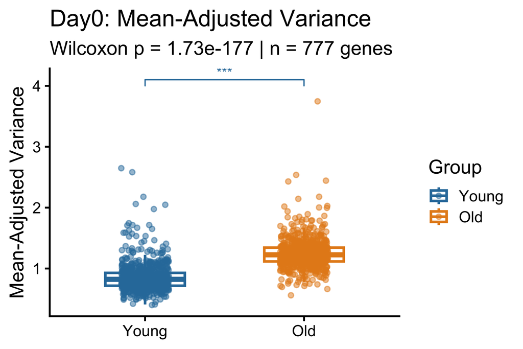

```r
dvg_plots$mean_adj_var_box
```

Global density plot showing the distribution of the variance between the two groups

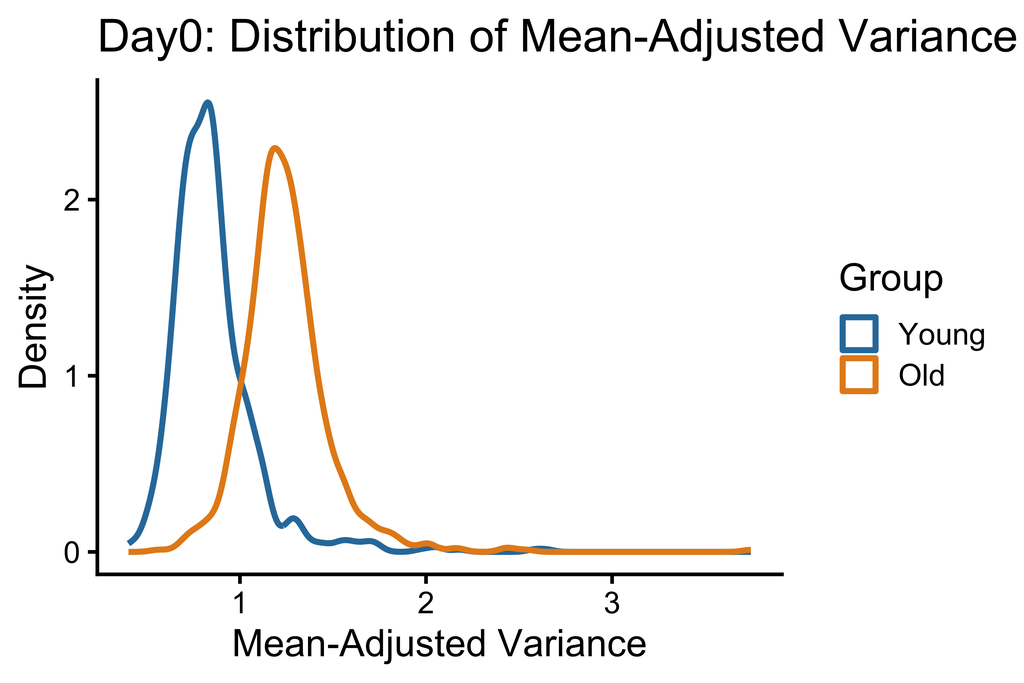

```r
dvg_plots$density_mean_adj
```

Volcano plot for differential variable genes (DVGs)

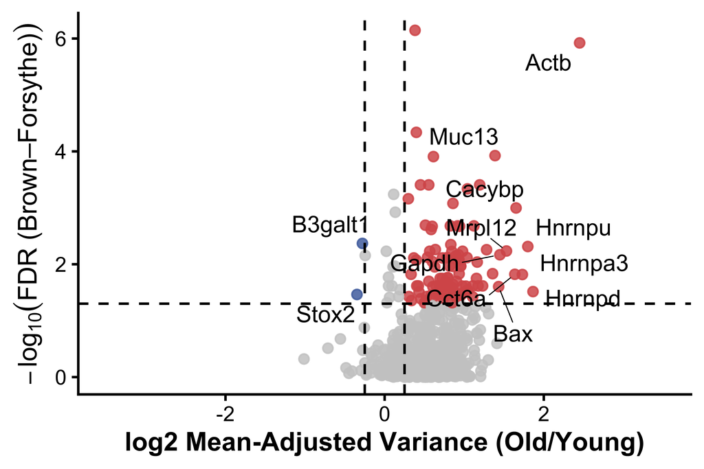

```r
dvg_plots$volcano_mean_adj
```

# Visualization of per-gene normalized experssion and heterogeneity

We can also visualized the expression pattern and the variance of the individual gene from the comparison groups using function plot_density_gene(), showing Eya1 as an example below:

```r
table(seurat_obj$donor_age)
```

```
#>
#> Young   Old
#>    69    67
```

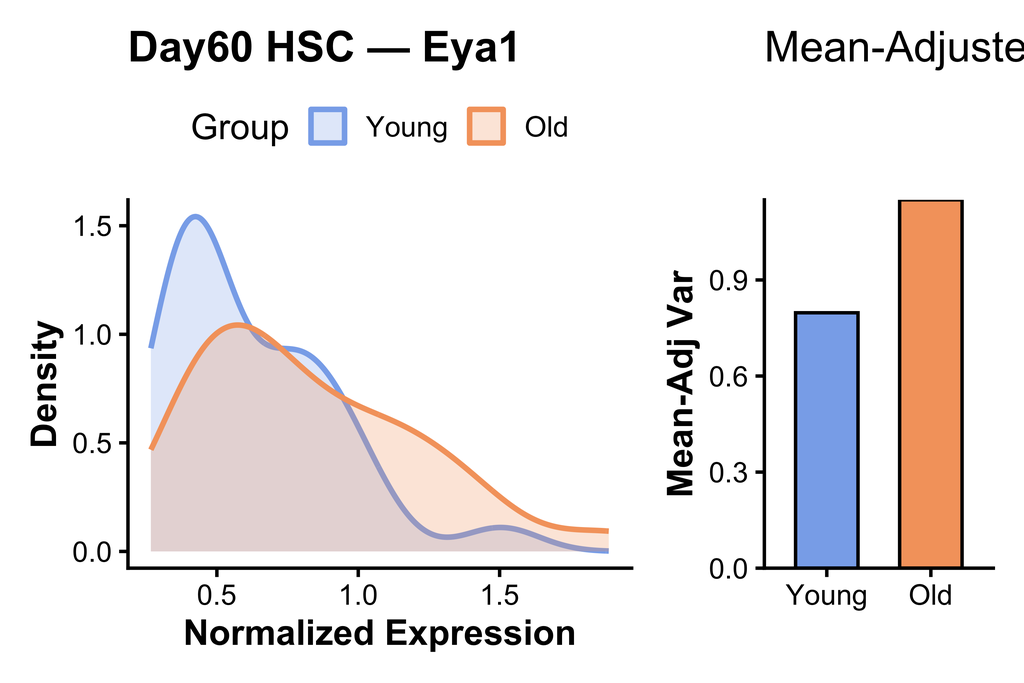

```r
plot_density_gene(
    seurat_obj = seurat_obj,
    gene = "Eya1",
    group_col = "donor_age",
    group1_labels = c("Y", "Young"),
    group2_labels = c("O", "Old"),
    group1_name = "Young",
    group2_name = "Old",
    title_prefix = "Day60 HSC",
    dvgs_df = dvg_out,
    mean_adj_var_group1_col = "mean_adjusted_var_Young",
    mean_adj_var_group2_col = "mean_adjusted_var_Old"
)
```

# GSEA Across MSigDB Collections

Performs enrichment analysis on ranked heterogeneity statistics.

Differential variability analysis identifies genes whose expression variability differs between biological conditions. However, gene-level results can be difficult to interpret biologically.

To address this, we perform Gene Set Enrichment Analysis (GSEA) using the ranked heterogeneity statistics to identify pathways whose genes collectively show increased or decreased transcriptional variability.

The function run_msigdb_gsea_all_collections() performs GSEA across multiple MSigDB gene set collections, enabling pathway-level interpretation of transcriptional heterogeneity changes.

## Method Overview

The workflow proceeds as follows:

Rank genes by heterogeneity statistic

Genes are ranked using a selected variable from the DVG results, typically:

log2 fold change of mean-adjusted variance

mean-adjusted variance score

other heterogeneity metrics

Example ranking variable:

```r
log2FC_mean_adjusted_variance
```

Map gene symbols to ENTREZ IDs

MSigDB gene sets are defined using ENTREZ identifiers, so gene symbols are converted before enrichment analysis. MsigDB Collections listed below: H, C2, C3, C4, C5, C6, C7, C8

Construct ranked gene list

A ranked vector is constructed:

$$geneList = {g_1, g_2, ..., g_n}$$
sorted by the heterogeneity statistic.

Higher-ranked genes correspond to greater variability increases in the comparison group.

```r
gsea_out <- run_msigdb_gsea_all_collections(
  hsc_results = dvg_out,species = "Mus musculus",
  rank_var = "log2FC_mean_adjusted_variance", top_n = 1,
  title_prefix = "HSC")
```

## Visualize the GSEA results

The function returns a patchwork style of GSEA plots based on the top_n parameter.

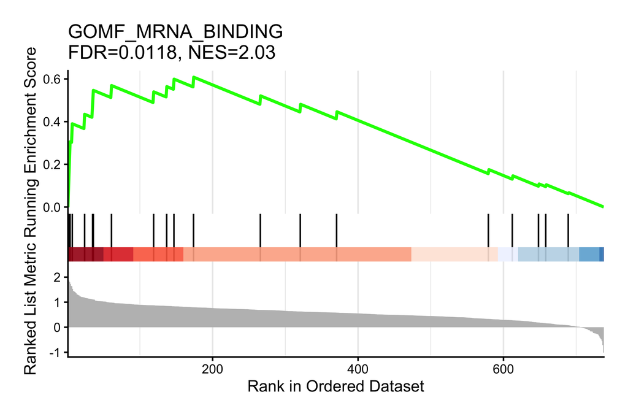

```r
gsea_out$per_collection$`C5:MF`$panel_up
```